# EU export and import to Russia and its neighbours

# Introduction

Russia war on Ukraine had an impact to EU and Russia trade. The goal of this document is to give a bird’s eye view of these changes. The data from Eurostat was used.

## Main findings

1. Export to Russia dropped by 47% after Russia invasion to Ukraine on February 24th. Export to Russia neighbours increased by 48%.
2. Sanctioned goods export to Russia fell by 71%. Sanctioned good export to Russia neighbours increased by 95%.
3. More that 100 sanctioned export markets has increased by 100% after the war and constitute 21% of total sanctioned exports. This strongly suggests that EU countries are evading sanctions by exporting to Russia neighbours instead.

# EU overall trade with Russia and neighbouring countries

Energy import constitutes about 70% of total imports. It distorts overall picture so it was excluded from the analysis. Energy exports constitute arounde 1% of total exports, but their calculation is complicated for countries connected to BRELL grid. For this reason it is excluded too.

In after war period EU countries exports to Russia fell by 47% to 36 billion euro compared to similar period in 2021. However EU countries export to Russia neighbours rose by 48% to 20 billion euro.

In after war period EU countries imports to Russia fell by 14% to 39 billion euro compared to similar period in 2021. EU countries import from Russia neighbours rose by 4% to 7 billion euro.

## Overall trade

### EU exports to Russia and neighbouring countries

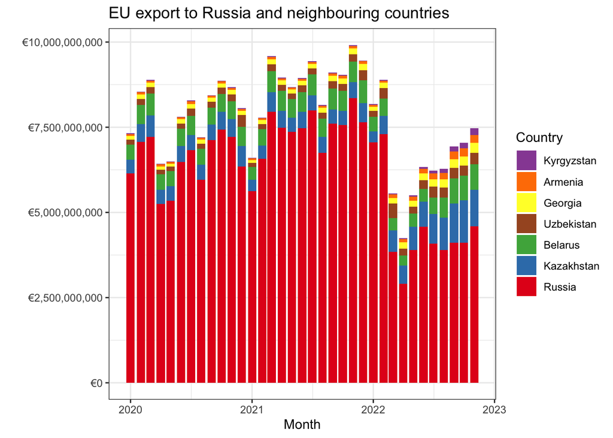

### EU export to Russia neighbours

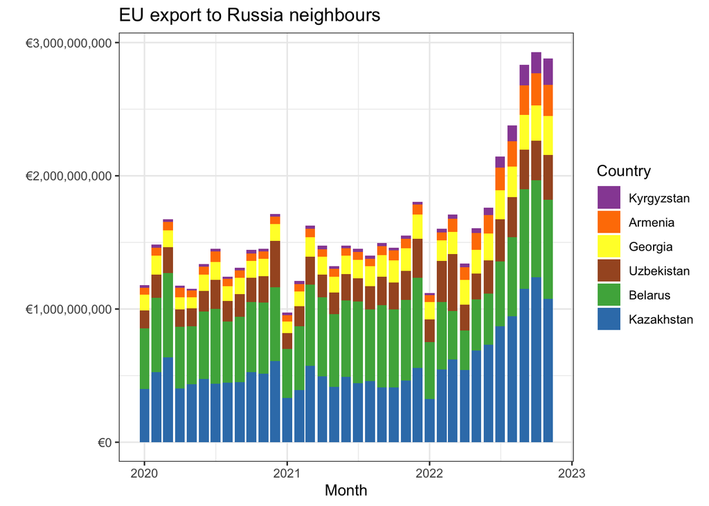

### EU import from Russia and neighbouring countries

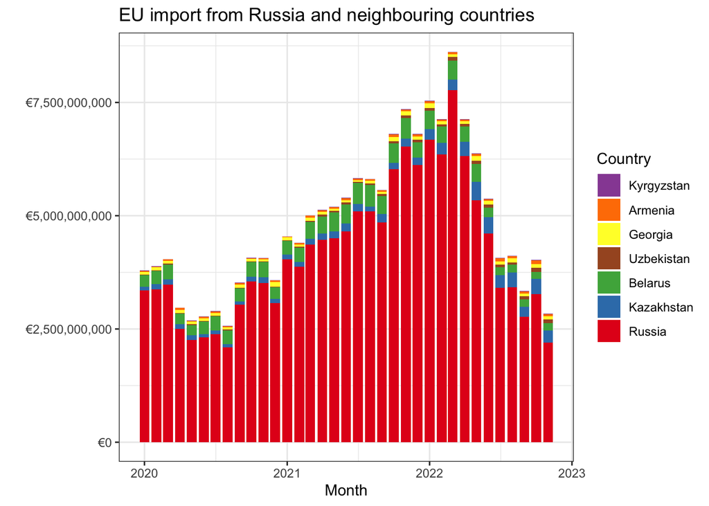

### EU import from Russia neighbours

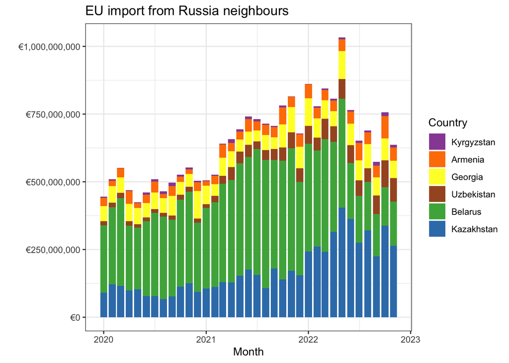

## Overall trade growth

Comparison is made between the months following the Russian invasion and corresponding months in 2021.

### EU export growth to Russia

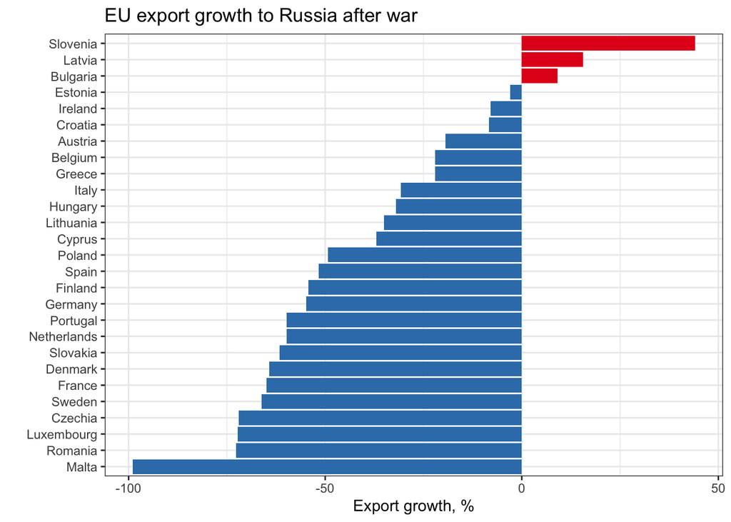

### EU export growth to Russia neighbours

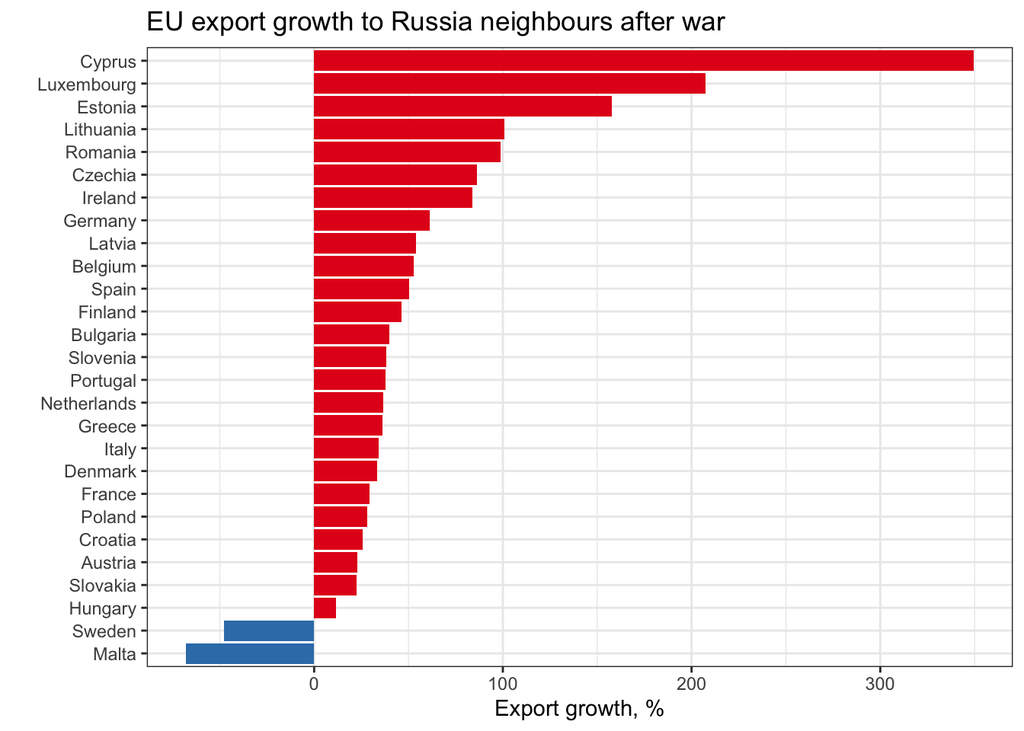

### EU import growth from Russia

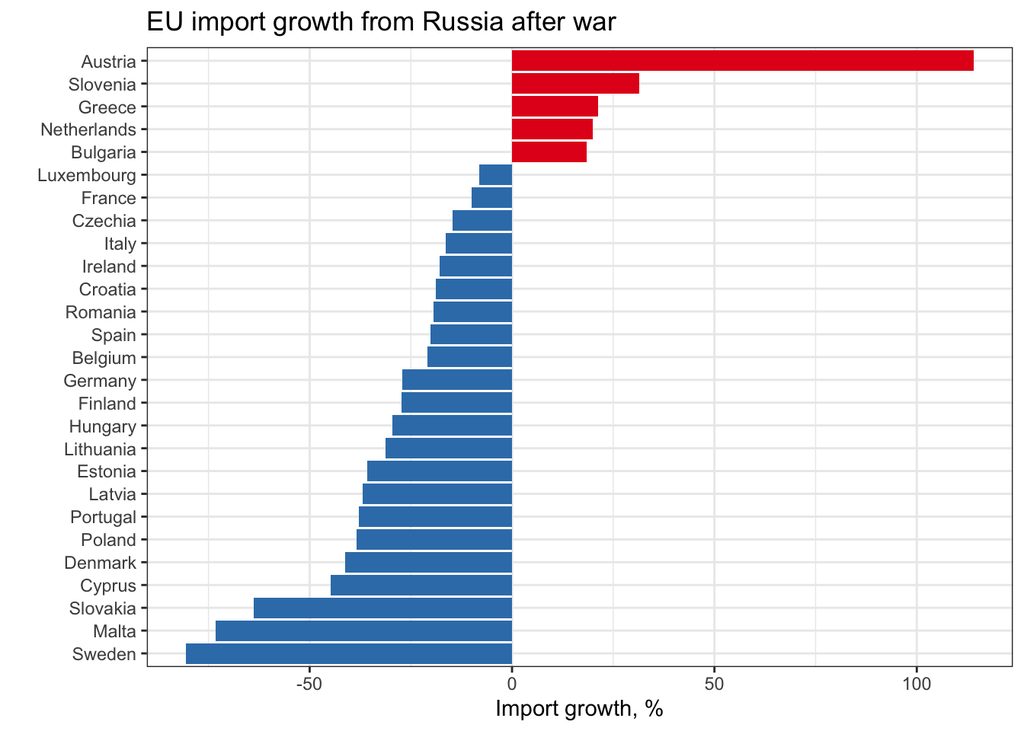

### EU import growth from Russia neighbours

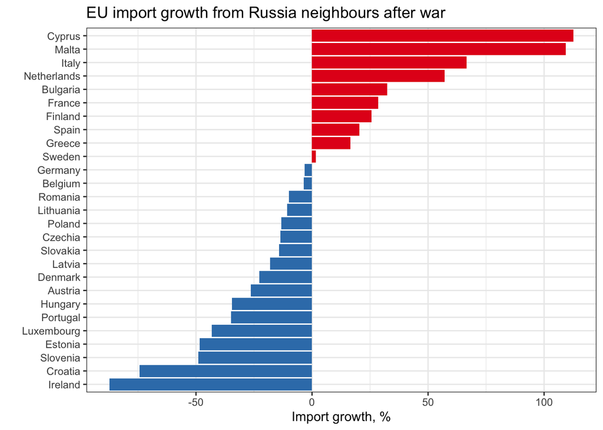

# Effect of sanctions on export

Sanctions put on exports are listed by their CN code in the following [document](https://eur-lex.europa.eu/legal-content/EN/TXT/?uri=CELEX%3A02014R0833-20221007). See Section 4 for technical details how the data was collected. The sanctions mentioned both CN 4 digits and CN 8 digits code. Only CN 8 digit codes were used for analysis.

There are quotas and exceptions for certain sanctioned goods, which allow export, so it is expected that sanctioned export is non zero. The effect of quotas and exceptions is not taken to account.

## Export of sanctioned goods

### To Russia with its neighbours

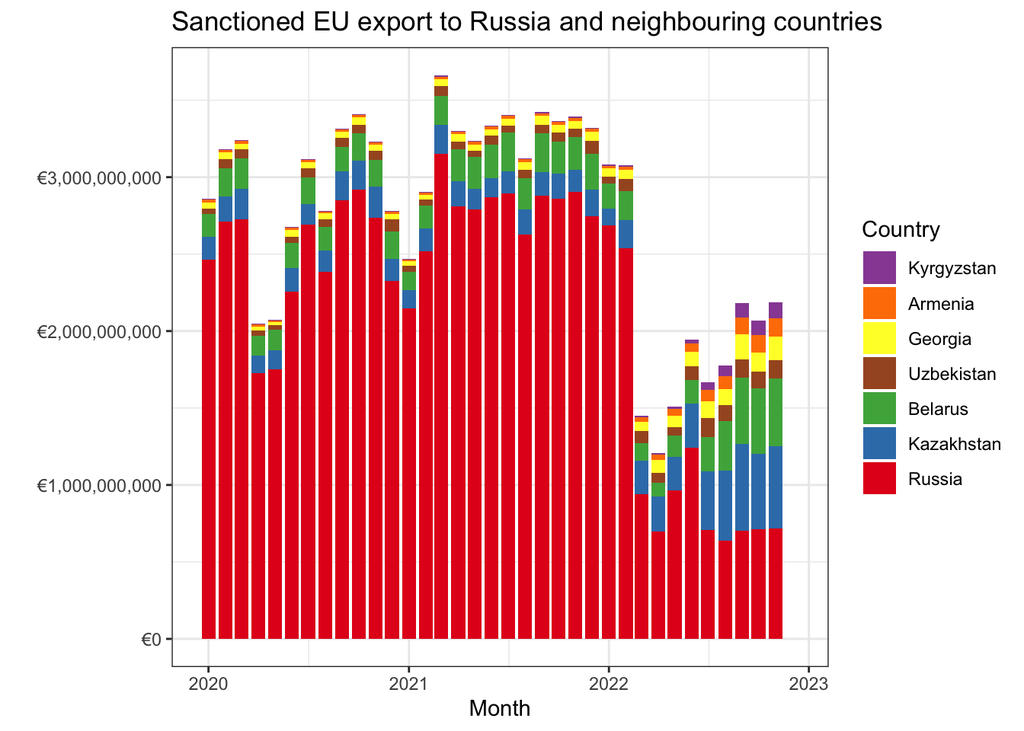

### To Russia neighbours

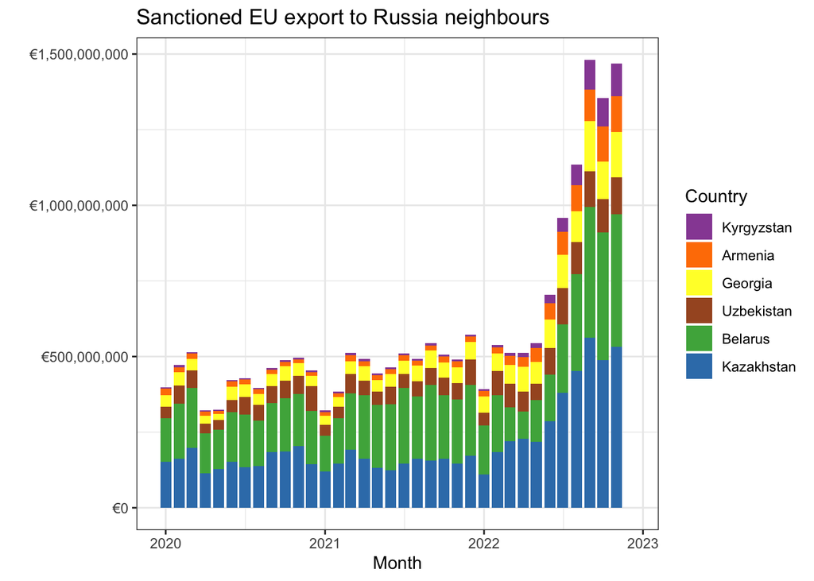

## Sanctioned export growth

### EU sanctioned export growth to Russia

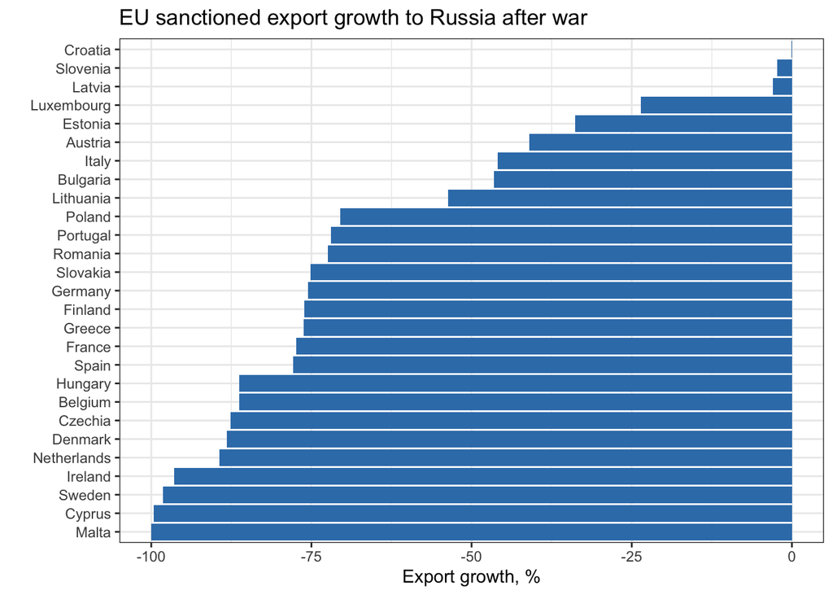

### EU sanctioned export growth to Russia neighbours

Malta sanctioned export grew by 4156% so it is not shown on the graph.

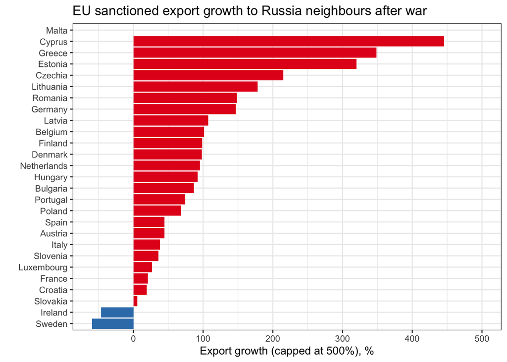

### EU sanctioned export

Absolute values Russian and its neighbours combined.

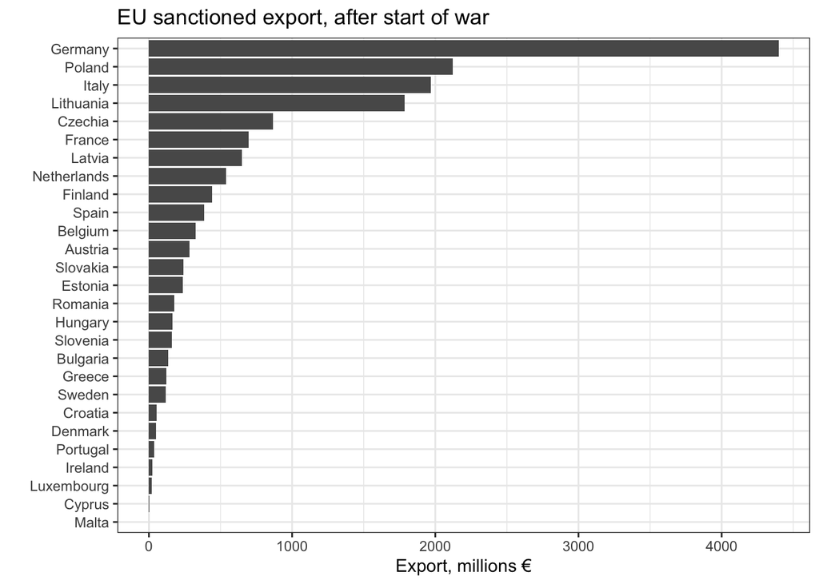

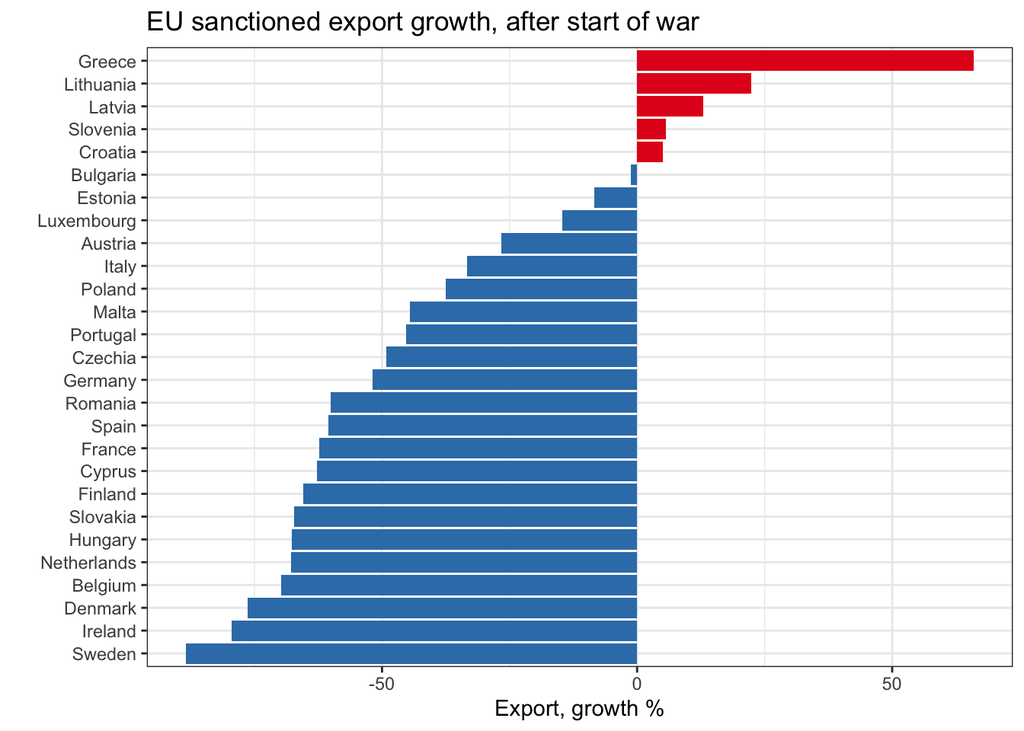

## Sanction anomalies

Export to Russia sanction evasion should be visible by increased export to other countries. Define anomaly as the export which is more than 10 million euro in value and which doubled after a war.

### Anomalous markets

Define by market an EU country, its export destination and good defined by 8 digit CN classifier.

Using the anomaly definition 118 export categories stand out. It is interesting that there are 25` categories of sanctioned exports to Russia which experienced triple digit growth.

The biggest of anomalous exports in term of value are motor cars. Lithuania topping the list with 173 millions euro export to Belarus which tripled compared to previous year. Germany exports of motor cars to Belarus and Russia grew ~8 times for cars with cylinder capacity between 1.5 and 2 litres. Germany exports of motor cars to Belarus with cylinder capacity larger than 2 litres grew 26 times. These Germany exports amounted to 422 milion euro of exports after the war.

Poland exported 139 millions of euro worth turbojets to Kazakhstan, and these exports grew 3 times. Czechia exported 233 millions euro of smartphones to Kazakhstan, Armenia and Georgia after the war, which is notable as in 2021 there were no such exports at the same period.

Latvia exported 43 millions euro worth of sparling wine to Russia and these exports grew 4 times.

Greece exported 75 millions euro worth of jet fuel to Georgia. These exports grew by ~4500 times compared to similar period in 2021.

| reporter | partner | code | product | value | growth |
| --- | --- | --- | --- | --- | --- |
| Lithuania | Belarus | 87033290 | Motor cars and other motor vehicles principally designed for the transport of &lt;10 persons, incl. station wagons and racing cars, with only diesel engine of a cylinder capacity &gt; 1.500 cm³ but &l… | 173719591 | 2.1535 |
| Czechia | Kazakhstan | 85171300 | Smartphones for wireless networks | 164529472 |  |
| Germany | Belarus | 87033290 | Motor cars and other motor vehicles principally designed for the transport of &lt;10 persons, incl. station wagons and racing cars, with only diesel engine of a cylinder capacity &gt; 1.500 cm³ but &l… | 158884606 | 7.399 |
| Germany | Belarus | 87033390 | Motor cars and other motor vehicles principally designed for the transport of &lt;10 persons, incl. station wagons and racing cars, with only diesel engine of a cylinder capacity &gt; 2.500 cm³, used … | 144141897 | 25.6421 |
| Poland | Kazakhstan | 84111280 | Turbojets of a thrust &gt; 132 kN | 139571734 | 2.1856 |
| Germany | Russia | 87033290 | Motor cars and other motor vehicles principally designed for the transport of &lt;10 persons, incl. station wagons and racing cars, with only diesel engine of a cylinder capacity &gt; 1.500 cm³ but &l… | 122162740 | 6.5866 |
| Latvia | Russia | 84283300 | Continuous-action elevators and conveyors for goods or materials, belt type (excl. those for underground use) | 83542419 | 45.173 |
| Germany | Russia | 84195080 | Heat-exchange units (excl. those used with boilers and those made of fluoropolymers with inlet and outlet tube bores with inside diameters measuring &lt;=3 cm) | 81086830 | 4.0785 |
| Germany | Kazakhstan | 87032410 | Motor cars and other motor vehicles principally designed for the transport of &lt;10 persons, incl. station wagons and racing cars, with only spark-ignition internal combustion reciprocating piston en… | 80030661 | 20.9908 |
| Lithuania | Belarus | 87033390 | Motor cars and other motor vehicles principally designed for the transport of &lt;10 persons, incl. station wagons and racing cars, with only diesel engine of a cylinder capacity &gt; 2.500 cm³, used … | 75923299 | 18.1877 |

[output cut: 108 more lines]

The growth with empty values in the table means that the export in year 2021 from March to November was zero. The full name of exported goods appears if you hover on truncated name.

# Appendix

## Data

The data used comes from Eurostat dataset on international trade in [goods](https://ec.europa.eu/eurostat/databrowser/view/DS-045409/legacyMultiFreq/table?lang=en).

All the code and data resides in the [Github repository](https://github.com/vzemlys/ruimpeks/):

1. [Code for this document](https://github.com/vzemlys/ruimpeks/blob/main/eu_ru_trade.qmd).
2. [Total trade data](https://github.com/vzemlys/ruimpeks/tree/main/xlsx).
3. [CN codes for export sanctions](https://github.com/vzemlys/ruimpeks/blob/main/raw/input_codes.csv).
4. [Sanctioned export data](https://github.com/vzemlys/ruimpeks/tree/main/raw) and the [code to prepare it](https://github.com/vzemlys/ruimpeks/blob/main/R/prepare_data.R).
5. [Sanctioned exports CN 8 digits codes](https://github.com/vzemlys/ruimpeks/blob/main/meta/export_sanctions_codes.csv).